# Tidy Tuesday - Week 8 (2022)

```r
library(tidyverse)
library(tidytuesdayR)

freedom <- readr::read_csv('https://raw.githubusercontent.com/rfordatascience/tidytuesday/master/data/2022/2022-02-22/freedom.csv')

head(freedom)
```

```
## # A tibble: 6 × 8
##   country      year    CL    PR Status Region_Code Region_Name is_ldc
##   <chr>       <dbl> <dbl> <dbl> <chr>        <dbl> <chr>        <dbl>
## 1 Afghanistan  1995     7     7 NF             142 Asia             1
## 2 Afghanistan  1996     7     7 NF             142 Asia             1
## 3 Afghanistan  1997     7     7 NF             142 Asia             1
## 4 Afghanistan  1998     7     7 NF             142 Asia             1
## 5 Afghanistan  1999     7     7 NF             142 Asia             1
## 6 Afghanistan  2000     7     7 NF             142 Asia             1
```

Objective: Recreate a version of [this graph](https://github.com/rfordatascience/tidytuesday/blob/master/data/2022/2022-02-22/pic2.png) from Freedom House which displays the number of countries improving or declining in their Freedom aggregate score over the course of 10 years (2006-2015). The score used for their graph fell from 30 to 80 while the aggregate score in the data (Political Rights and Civil Liberties combined) falls on a scale of 1 to 14, so the final data look a bit different plotted on the graph below.

```r
library(reshape2)

freedom_dec <- freedom %>%
  filter(year > 2004) %>%
  filter(year <= 2015) %>%
  select(country, year, CL, PR, Status)

freedom_dec$agg <- freedom_dec$CL + freedom_dec$PR # aggregate freedom score

freedom_dec <- freedom_dec %>%
  group_by(country) %>%
  mutate(diff = agg - lag(agg, default = first(agg))) %>% # change from year to year
  select(country, year, agg, diff)

counts <- freedom_dec %>% # get rid of observations with no change
  filter(diff != 0)

counts$Status <- ifelse(counts$diff > 0, "DECLINED", "IMPROVED") # positive changes are a decline because
                                                                 # higher scores means lower freedom levels

# count the number of declines and improvements in the data
counts <- counts %>%
  group_by(year) %>%
  count(Status) %>%
  filter(year > 2005)

n <- counts %>%
  filter(Status == "IMPROVED") %>%
  select(n, Status)

totals <- counts %>%
  group_by(year) %>%
  mutate(n2 = sum(n))

totals <- unique(totals) # create a data frame with total countries for each year

sums <- left_join(n, totals) # keep improved numbers

sums <- as.data.frame(melt(sums, id.vars = c("Status", "year"))) %>%
  select(-Status, -variable)

sums <- rbind(sums[11:20, ], sums[1:10, ]) %>% # reorder for graphing
  arrange(year)

value <- select(sums, value)

counts <- cbind(counts, value)
```

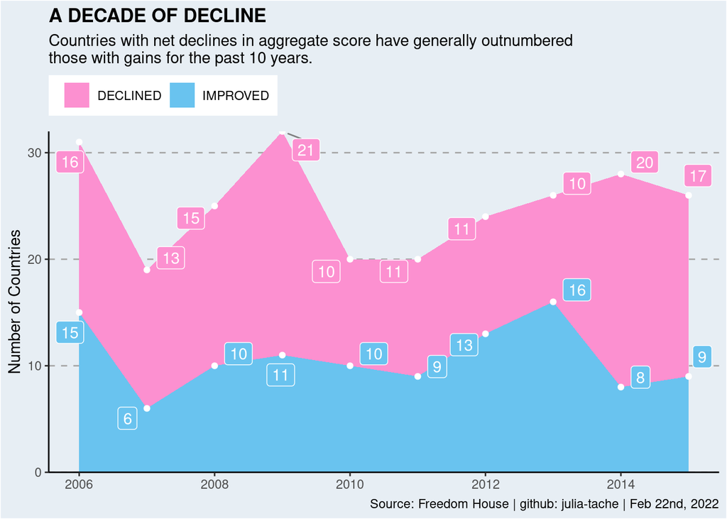

```r
library(ggrepel)
library(scales)

ggplot(counts, aes(x = year, y = n, fill = Status)) +
  geom_area() +
  geom_area(alpha=0.6 , size=.5)  +
  scale_fill_manual(values = c("#FC90D0", "#69C3EF")) +
  geom_point(aes(x = year, y = value), color = "white") +
  geom_label_repel(aes(x = year, y = value, label = n),
                   box.padding   = 0.35,
                   point.padding = 0.5,
                   segment.color = "grey50",
                   color = "white") +
  guides(fill = guide_legend(title = "Status", override.aes = aes(label = ""))) +
  ylab("Number of Countries") +
  theme_classic() +
  theme(panel.background = element_rect(fill = "#E7EEF4"),
        plot.background = element_rect(fill = "#E7EEF4"),
        panel.grid.major.y = element_line(colour = "dark gray", linetype = "dashed"),
        legend.position = "top",
        legend.justification = 'left',
        plot.title = element_text(face  ="bold"),
        legend.title = element_blank(),
        axis.title.x = element_blank()) +
  scale_x_continuous(breaks= pretty_breaks()) +
  scale_y_continuous(expand = c(0, 0)) +
  labs(title = "A DECADE OF DECLINE",
       subtitle = "Countries with net declines in aggregate score have generally outnumbered \nthose with gains for the past 10 years.",
       caption = "Source: Freedom House | github: julia-tache | Feb 22nd, 2022")
```

```r
ggsave("area_graph.png")
```

The chart is titled “A Decade of Decline, Countries with net declines in aggregate score have generally outnumbered those with gains for the past 10 years.”

The area chart displays year on the x-axis from 2006 to 2015 and the number of countries improving or declining in their Freedom aggregate score from 0 to 30 on the y-axis. 16, 13, 15, 21, 10, 11, 11, 10, 20, and 17 countries declined in their scores from 2006 to 2015. Improved countries were 15, 6, 10, 11, 10, 9, 13, 16, 8, 9 from 2006 to 2015.